# Impact of Protection Status on California Spiny Lobster

Zoe Duerksen-Salm and Audrey Nolan

11/18/2019

### Introduction

The California spiny lobster (*Panulirus interruptus*) plays a key role in maintaining the health of giant kelp forests. Spiny lobsters forage algae, snails, crabs, and sea urchins, helping regulate species that prey on kelp, in turn sustaining kelp forest ecosystems<sup>[1](https://portal.edirepository.org/nis/mapbrowse?scope=knb-lter-sbc&identifier=77&revision=newest)</sup>. The natural distribution of the spiny lobster ranges from the coast of Santa Barbara, California to the Gulf of Tehuantepec, Mexico<sup>[2](https://scripps.ucsd.edu/zooplanktonguide/species/panulirus-interruptus)</sup>. Unfortunately, spiny lobster populations are threatened by fishing pressures, ultimately inhibiting their ability to grow, both in population size and individual lobster length. In 2012, two sites along the coast of Santa Barbara - Naples and Isla Vista - were established as marine protected areas (MPAs) to preserve spiny lobster populations. Under the Marine Life Protection Act, MPAs aim to preserve the biodiversity of marine life, the ecompassed habitats, and the natural aspects of marine ecosystems<sup>[3](https://www.wildlife.ca.gov/Conservation/Marine/MPAs)</sup>. The designation of MPA sites allows for a comparison of ecosystem health and variability between protected sites and unregulated areas.

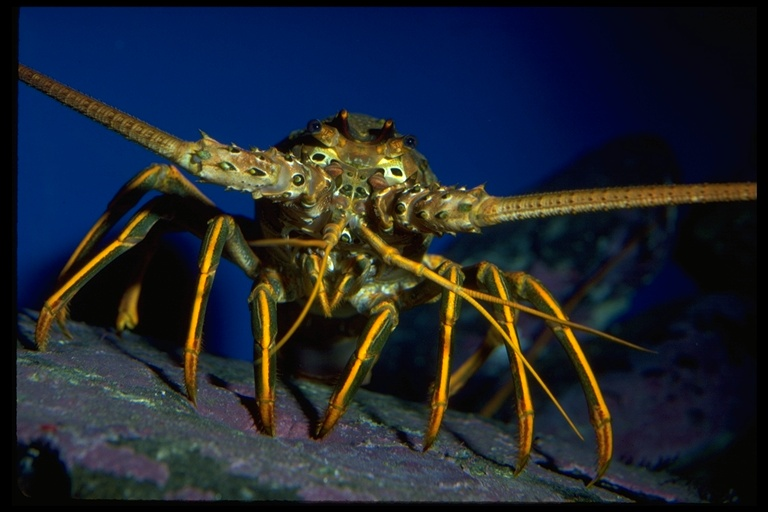

Spiny Lobster Image Source<sup>[4](https://calphotos.berkeley.edu/cgi/img_query?enlarge=9092+3191+3541+0006)</sup>

### Data and Methods

The spiny lobster abundance and size data was obtained by Santa Barbara Coastal Long Term Ecological Research (SBC LTER). In 2012, researchers at SBC LTER began collecting data on spiny lobster populations at five sites along the coast of Santa Barbara. Sampling data includes abundance, size, and fishing pressure. Lobster counts and lobster size (mm) were recorded by divers in four 300m<sup>2</sup> lobster transects. This data is collected annually in late summer at each of the five sites along the Santa Barbara Channel<sup>[1](https://portal.edirepository.org/nis/mapbrowse?scope=knb-lter-sbc&identifier=77&revision=newest)</sup>. Lobster size and abundance are two main varibles assessed within this report.

Spiny lobster abundance and size across all five sites, discerning between MPA protection status, was visually analyzed via histograms and distribution plots. Statistical tests were performed on the data including a Whelch Two Sample t-test with a significance level of p = 0.05. All statistical analyses and figures were prepared using R software version 3.6.1.

MPA sites established in 2012 - Isla Vista and Naples - are represented by orange coloration in all figures throughout this report. Non-MPA sites - Arroyo Quemado, Carpinteria, Mohawk - are indicated with blue coloration.

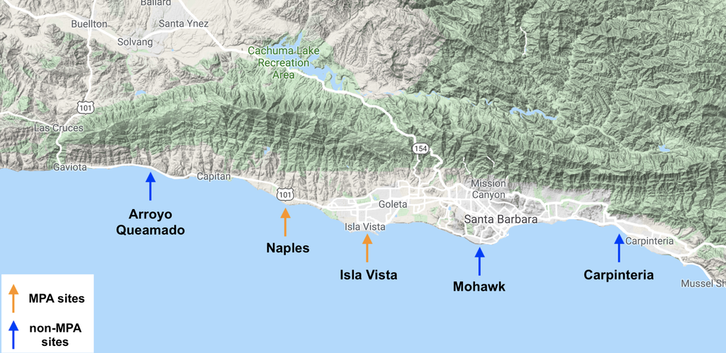

Site Map Image Source<sup>[1](https://portal.edirepository.org/nis/mapbrowse?scope=knb-lter-sbc&identifier=77&revision=newest)</sup>